# Gradient Descent

In this post, we are going to discuss *Gradient Descents*; what it is and how to use it. Gradient Descent is used in many machine learning algorithms to find the local miniumum in differentiable functions where there is a linear relationship. It goes hand in hand with optimization problems. In this tutorial, we will focus on linear regressions. A linear regression is used to model the relationship between one or more variables. In our case, we have an input $x$ and an output $y$, but we do not know the slope $m$ or the intercept $b$.

$$y = mx + b$$

To build our model, we need to tune two parameters, namely $m$ and $b$. To do so, we need to use the mean squared error (MSE) as our loss function. This function measures the average squared difference between the estimated values and the actual value. We expect this to be 0 if our predicted values equal our actual value.

$$MSE = \frac{1}{N}\Sigma_{i=1}^{n}(Y_{i}-\hat Y_{i})^{2}$$
Therefore, we will need optimize the MSE for a linear regression using the gradient descent. A gradient is defined as follows:

$$\nabla J(\theta) = [\frac{\partial J}{\partial \theta_{1}}, \frac{\partial J}{\partial \theta_{2}}, ..., \frac{\partial J}{\partial \theta_{p}}]$$
The gradient descent is defined in the following equation. The algorithm will iterate over and over using the gradient descent to find new values of $m$ and $b$. This will continue until MSE converges to zero, letting us know that our predicted values equal to our actual values.

$$\theta_{n + 1} = \theta_{n} - \eta \nabla J(\theta_{n})$$

Let’s first solve for $\nabla J(\theta_{n})$ by plugging in the MSE equation and finding the partial derivatives with respect to $m$ and $b$.

$$MSE = \frac{1}{N}\Sigma_{i=1}^{n}(y_{i}-(mx_{i}+b))^{2}$$

$$f(m,b) = \frac{1}{N}\Sigma_{i=1}^{n}(y_{i}-(mx_{i}+b))^{2}$$
$$\frac{\partial f(m,b)}{\partial m} = \frac{1}{N}\Sigma_{i=1}^{n}-2(y_{i}-(mx_{i}+b)) \frac{\partial f}{\partial m}(mx_{i}+b))$$
$$\frac{\partial f(m,b)}{\partial m} = \frac{1}{N}\Sigma_{i=1}^{n}-2x_{i}(y_{i}-(mx_{i}+b))$$

$$\frac{\partial f(m,b)}{\partial b} = \frac{1}{N}\Sigma_{i=1}^{n}-2(y_{i}-(mx_{i}+b)) \frac{\partial f}{\partial b}(mx_{i}+b))$$
$$\frac{\partial f(m,b)}{\partial b} = \frac{1}{N}\Sigma_{i=1}^{n}-2(y_{i}-(mx_{i}+b))$$
Now we have our two final equations. We can begin implementing them.

$$\hat m = m - \eta(\frac{1}{N}\Sigma_{i=1}^{n}-2x_{i}(y_{i}-(mx_{i}+b)))$$

```r
gradient_descent <- function(x,y, epsilon = 0.001, lr = 0.001, steps = 10000){
  epsilon = 0.0001
  m = runif(1) #Initialize a random number
  b = runif(1) #Initialize a random number
  N = length(x)
  log = c()
  mseloss = c()
  for (step in 1:steps){
    f = y - (m*x + b) #Subtracting the estimated value from the actual value
    mseloss = c(mseloss, sum(f ** 2) / N)
    dm <- -2 / N * sum(x %*% f)
    db <- -2 / N * sum(f)
    m = m - lr * dm
    b = b - lr * db
    log = rbind(log, c(m,b))
    if (sum(f ** 2) / N <= epsilon){ #stop the algorithm once we have converged to zero
      break
    }
  }
  list = list('m' = m, 'b' = b, 'steps' = step, 'log' = log, 'mseloss' = mseloss)
  return(list)
}
```

We can intialize a simple example by setting `x = c(1,2,3,4,5)` and `y = 2 * x`. We expect `m = 2` and `b = 0`.

```r
x = c(1,2,3,4,5)
y = 2 * x
res <- gradient_descent(x,y)
res$m
```

```
[1] 1.990115
```

```r
res$b
```

```
[1] 0.035689
```

```r
res$m * x + res$b
```

```
[1] 2.025804 4.015918 6.006033 7.996148 9.986263
```

We can observe convergance by plotting the MSE against the number of iterations.

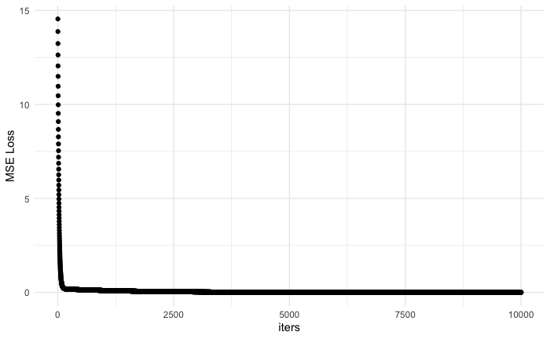

```r
df <- data.frame('iters' = 1:res$steps, 'mseloss' = res$mseloss)
ggplot(df, aes(x = iters, y = mseloss)) + geom_point() + theme_minimal() + ylab('MSE Loss')
```

```r
print('The predicted values are:')
```

```
[1] "The predicted values are:"
```

```r
head(res$m * x + res$b)
```

[output not shown]

```r
print('The actual values are:')
```

```
[1] "The actual values are:"
```

```r
head(y)
```

[output not shown]

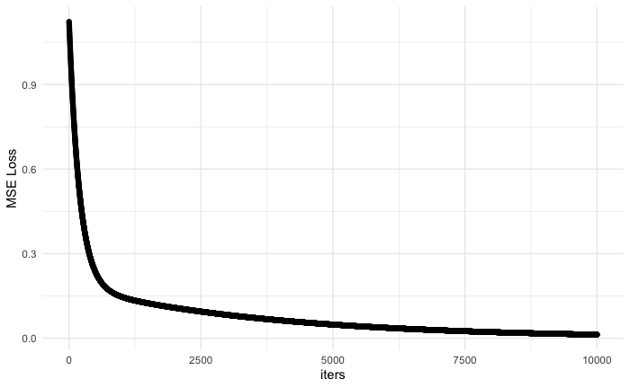

```r
df <- data.frame('iters' = 1:res$steps, 'mseloss' = res$mseloss)
ggplot(df, aes(x = iters, y = mseloss)) + geom_point() + theme_minimal() + ylab('MSE Loss')
```

As you can see, the predicted values don’t match the actual values. In addition, the MSE loss does not converge. This suggests we may need more iterations. Let’s try with 50,000 iterations.

```r
ptm <- proc.time()
res <- gradient_descent(x,y, steps = 50000)
proc.time() - ptm
```

```
   user  system elapsed
 10.156   5.408  15.611
```

```r
res$m
```

```
[1] 1.965905
```

```r
res$b
```

```
[1] 0.0184067
```

```r
head(res$m * x + res$b)
```

[output not shown]

```r
head(y)
```

```
[1] 0.1618990 1.8067891 1.2825891 0.3667304 1.9687269 0.9009622
```

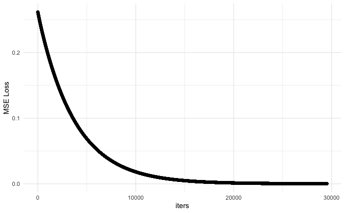

```r
df <- data.frame('iters' = 1:res$steps, 'mseloss' = res$mseloss)
ggplot(df, aes(x = iters, y = mseloss)) + geom_point() + theme_minimal() + ylab('MSE Loss')
```

Now it looks like we have converged and reached an optimal value. However, the time it took was much longer. To wrap up, we were able to determmine a suitable $m$ and $b$ to satisfy our optimization problem. However, this algorithm can be slow if we are working with large matrices. In that case, we can use *Stochastic Gradient Descent* and use only a subset of the matrix with one sample at a time for the optimimization.

Let’s see what this would look like.

```r
s_gradient_descent <- function(x,y, epsilon = 0.001, lr = 0.001, steps = 10000, batch_size = 1){
  epsilon = 0.0001
  m = runif(1) #Initialize a random number
  b = runif(1) #Initialize a random number
  log = c()
  mseloss = c()
  for (step in 1:steps){
    index <- sample.int(length(y), batch_size)
    N = length(index)
    Xs <- x[index]
    Ys <- y[index]
    f = Ys - (m*Xs + b) #Subtracting the estimated value from the actual value
    mseloss = c(mseloss, sum(f ** 2) / N)
    dm <- -2 / N * sum(Xs %*% f)
    db <- -2 / N * sum(f)
    m = m - lr * dm
    b = b - lr * db
    log = rbind(log, c(m,b))
    if (sum(f ** 2) / N <= epsilon){ #stop the algorithm once we have converged to zero
      break
    }
  }
  list = list('m' = m, 'b' = b, 'steps' = step, 'log' = log, 'mseloss' = mseloss)
  return(list)
}
```

```r
print('The predicted values are:')
```

```
[1] "The predicted values are:"
```

```r
head(sgd_res$m * x + sgd_res$b)
```

```
[1] 0.1798753 1.7924019 1.2785156 0.3806765 1.9511535 0.9043973
```

```r
print('The actual values are:')
```

```
[1] "The actual values are:"
```

```r
head(y)
```

```
[1] 0.1618990 1.8067891 1.2825891 0.3667304 1.9687269 0.9009622
```

Additonal Resources: